# Trindidad Fish Predation

Faith Jones

9 June 2017

below is the initial analysis i have done to look at variability in predator mass in streams. I have used only the 2010-2015 data as this is what i recieved from Faye.

```r
library(dplyr)
library(tidyr)
library(ggplot2)
library(lme4)

setwd("C:\\Users\\faj\\Documents\\OneDrive for Business\\research\\FishPredation\\Data")
fishData <- read.csv("FishData.csv")
```

## Biomass variability in predators initial analysis

```r
#sum biomass per site and year
predatorsBioN <- fishData %>%
    filter(Species == "Rivulus hartii" | Species == "Crenicichla frenata") %>%
    separate(Date, c("Day", "Month", "Year"), sep = "/") %>%
    group_by(Site, Year) %>%
    summarise(BiomassSum = sum(weight))

predatorsBio <- data.frame(predatorsBioN)
predatorsBio$Year <- as.numeric(predatorsBio$Year )
head(predatorsBio)
```

```
##      Site Year BiomassSum
## 1 Acono d 2010       11.2
## 2 Acono d 2011      181.6
## 3 Acono d 2012      126.0
## 4 Acono d 2013      338.2
## 5 Acono d 2014      130.0
## 6 Acono d 2015      271.0
```

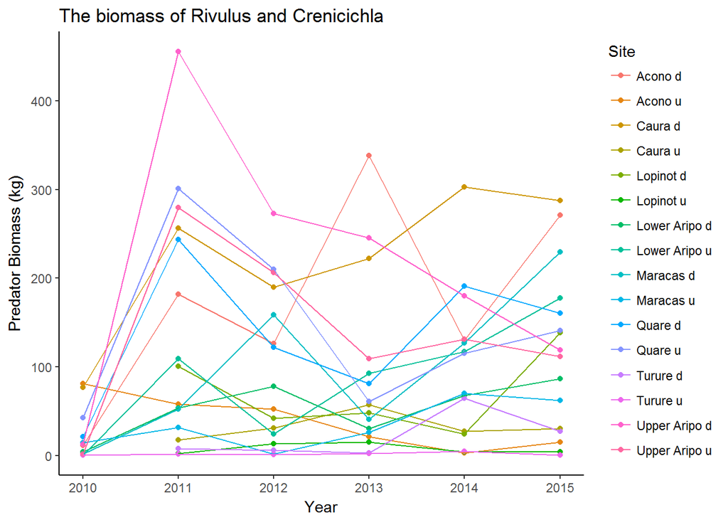

```r
BioPlot <- ggplot(predatorsBio, aes(x = Year, y = BiomassSum, col = Site, group = Site))
BioPlot + geom_point() +
    geom_line() +
    theme_classic() +
    labs(title="The biomass of Rivulus and Crenicichla", y = "Predator Biomass (kg)")
```

I then took a look at the coefficients of variation between sites and between years

```r
#variation between sites
cvSitesb <- predatorsBio %>%
  group_by(Site) %>%
  summarise(meanSite = mean(BiomassSum), sdSite = sd(BiomassSum))%>%
  mutate(cvSite = sdSite/meanSite)
cvSitesBio <- data.frame(cvSitesb)
print(cvSitesBio)
```

```
##             Site   meanSite     sdSite    cvSite
## 1        Acono d 176.333333 115.878879 0.6571581
## 2        Acono u  38.400000  29.997067 0.7811736
## 3        Caura d 222.516667  82.666884 0.3715087
## 4        Caura u  32.600000  14.696428 0.4508107
## 5      Lopinot d  70.560000  47.439677 0.6723310
## 6      Lopinot u   7.580000   5.949118 0.7848440
## 7  Lower Aripo d  53.250000  31.299057 0.5877757
## 8  Lower Aripo u  86.816667  64.953966 0.7481739
## 9      Maracas d 101.516667  85.343106 0.8406807
## 10     Maracas u  34.233333  26.879931 0.7851976
## 11       Quare d 136.600000  79.535703 0.5822526
## 12       Quare u 144.850000  96.990407 0.6695920
## 13      Turure d  21.520000  25.777160 1.1978234
## 14      Turure u   1.733333   1.643979 0.9484494
## 15 Upper Aripo d 214.200000 150.702449 0.7035595
## 16 Upper Aripo u 139.833333  94.780729 0.6778121
```

```r
#variation between years
cvYearb <- predatorsBio %>%
  group_by(Year) %>%
  summarise(meanYear = mean(BiomassSum), sdYear = sd(BiomassSum))%>%
  mutate(cvSite = sdYear/meanYear)
cvYearBio <- data.frame(cvYearb)
print(cvYearBio)
```

```
##   Year meanYear    sdYear    cvSite
## 1 2010  22.2500  28.95999 1.3015725
## 2 2011 134.4313 135.99438 1.0116277
## 3 2012  95.8625  88.83434 0.9266850
## 4 2013  86.9750  97.61314 1.1223127
## 5 2014  97.4000  81.95428 0.8414197
## 6 2015 116.3312  92.50717 0.7952048
```

Finally i put together a mixed model of predator biomass against year with site as a random variable, to see how much of the variation in the mean values coudl be explainedby site differences. I am not sure this is the right way to go though. You can see from teh results that sites is accounting for quite a bit of variation, but other residual sources of variation are also important. I looked at teh standard deviation of the varience of the Random Effects to come to this conclusion.

```r
#add mean centered year for further analysis
meanYear <-summarise(predatorsBio, meanYear = mean(Year))
predatorsBio$meanYear <- meanYear[1,]
predatorsBio$meanCentredYear <-  predatorsBio$Year - predatorsBio$meanYear

##try a mixed model for biomass
#-------------------------------
bioM1 <- lmer(BiomassSum ~ meanCentredYear + (1|Site), data = predatorsBio)
summary(bioM1)
```

```
## Linear mixed model fit by REML ['lmerMod']
## Formula: BiomassSum ~ meanCentredYear + (1 | Site)
##    Data: predatorsBio
##
## REML criterion at convergence: 1062.8
##
## Scaled residuals:
##     Min      1Q  Median      3Q     Max
## -2.1550 -0.4789 -0.1028  0.3363  3.8259
##
## Random effects:
##  Groups   Name        Variance Std.Dev.
##  Site     (Intercept) 4477     66.91
##  Residual             5234     72.35
## Number of obs: 92, groups:  Site, 16
##
## Fixed effects:
##                 Estimate Std. Error t value
## (Intercept)       92.996     18.357   5.066
## meanCentredYear   10.296      4.569   2.253
##
## Correlation of Fixed Effects:
##             (Intr)
## meanCntrdYr -0.003
```

## Abundance variability in predators initial analysis

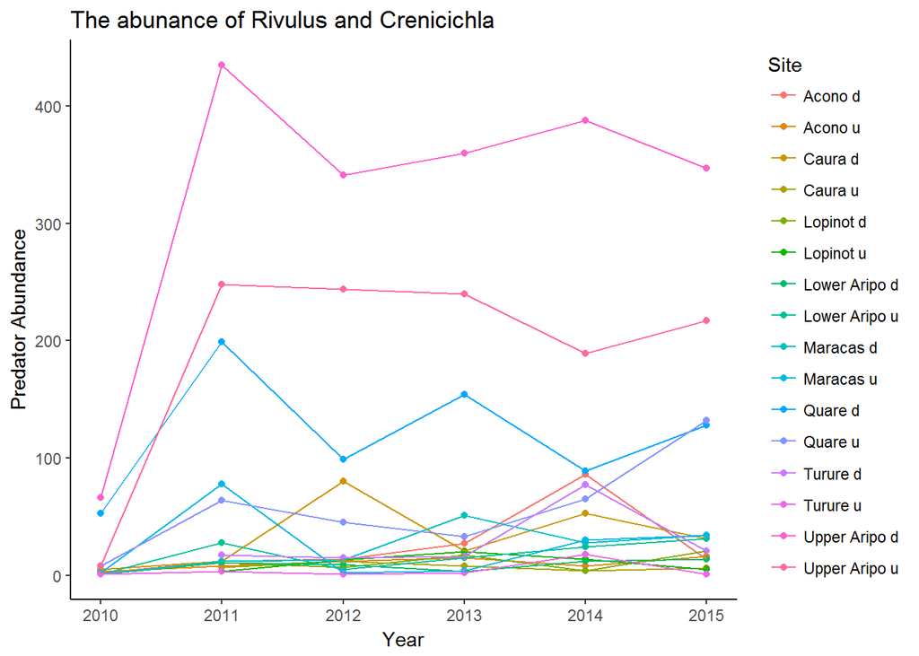

```r
predatorsAbN <- fishData %>%
    filter(Species == "Rivulus hartii" | Species == "Crenicichla frenata") %>%
    separate(Date, c("Day", "Month", "Year"), sep = "/") %>%
    group_by(Site, Year) %>%
    summarise(AbundanceSum = sum(number.caught))

predatorsAb <- data.frame(predatorsAbN)
predatorsAb$Year <- as.numeric(predatorsAb$Year)

AbPlot <- ggplot(predatorsAb, aes(x = Year, y = AbundanceSum, col = Site, group = Site))
AbPlot + geom_point() +
    geom_line() +
    theme_classic() +
    labs(title="The abunance of Rivulus and Crenicichla", y = "Predator Abundance")
```

Again, I took a look at the coefficients of variation between sites and over time.

```r
#add mean centered year for further analysis
meanYear <-summarise(predatorsAb, meanYear = mean(Year))
predatorsAb$meanYear <- meanYear[1,]
predatorsAb$meanCentredYear <-  predatorsAb$Year - predatorsAb$meanYear

#variation between sites
cvSitesa <- predatorsAb %>%
  group_by(Site) %>%
  summarise(meanSite = mean(AbundanceSum), sdSite = sd(AbundanceSum))%>%
  mutate(cvSite = sdSite/meanSite)
cvSitesAb <- data.frame(cvSitesa)
print(cvSitesAb)
```

```
##             Site   meanSite     sdSite    cvSite
## 1        Acono d  25.833333  30.531405 1.1818608
## 2        Acono u  10.333333   4.926121 0.4767214
## 3        Caura d  33.666667  28.211109 0.8379537
## 4        Caura u   7.400000   2.966479 0.4008756
## 5      Lopinot d  12.000000   7.000000 0.5833333
## 6      Lopinot u  11.000000   6.964194 0.6331086
## 7  Lower Aripo d   8.333333   5.202563 0.6243076
## 8  Lower Aripo u  17.333333  12.404300 0.7156327
## 9      Maracas d  23.166667  18.082220 0.7805275
## 10     Maracas u  25.000000  29.711950 1.1884780
## 11       Quare d 120.333333  51.674623 0.4294290
## 12       Quare u  57.833333  42.082855 0.7276574
## 13      Turure d  29.200000  26.817904 0.9184214
## 14      Turure u   4.333333   6.742897 1.5560533
## 15 Upper Aripo d 322.833333 130.450629 0.4040804
## 16 Upper Aripo u 191.000000  92.334176 0.4834250
```

```r
#variation between years
cvYeara <- predatorsAb %>%
  group_by(Year) %>%
  summarise(meanYear = mean(AbundanceSum), sdYear = sd(AbundanceSum))%>%
  mutate(cvYear = sdYear/meanYear)
cvYearAb <- data.frame(cvYeara)
print(cvYearAb)
```

```
##   Year meanYear    sdYear   cvYear
## 1 2010 12.58333  22.23616 1.767112
## 2 2011 71.75000 121.11124 1.687962
## 3 2012 57.00000  97.72956 1.714554
## 4 2013 61.62500 102.14426 1.657513
## 5 2014 68.06250  97.79057 1.436776
## 6 2015 65.75000  95.90377 1.458612
```

Finnaly, I ran a mixed model of predatpor abundance against time with site as a random variable to see how much variation could be explained by be differences in sites. In thsi model you can see that quite a lot of the variation from the mean can be attributed to site (standard deviation of 85 for site vs 45 for other residual error). You can also see in the plot that different sites generraly remain either high or low predator pressure as we move through the years.

```r
AbM1 <- lmer(AbundanceSum ~ meanCentredYear + (1|Site), data = predatorsAb)
summary(AbM1)
```

```
## Linear mixed model fit by REML ['lmerMod']
## Formula: AbundanceSum ~ meanCentredYear + (1 | Site)
##    Data: predatorsAb
##
## REML criterion at convergence: 996.9
##
## Scaled residuals:
##     Min      1Q  Median      3Q     Max
## -4.9856 -0.2612 -0.0917  0.2475  3.0236
##
## Random effects:
##  Groups   Name        Variance Std.Dev.
##  Site     (Intercept) 7267     85.25
##  Residual             2030     45.06
## Number of obs: 92, groups:  Site, 16
##
## Fixed effects:
##                 Estimate Std. Error t value
## (Intercept)       56.191     21.826   2.574
## meanCentredYear    8.114      2.849   2.848
##
## Correlation of Fixed Effects:
##             (Intr)
## meanCntrdYr -0.002
```

## Conclusions so far

Biomass does not seem so be an ideal way of quantifying whether a site is high or low predation. A single site’s predator biomass can vary as much over time as the difference between a high and low predator site in a singel year. So you may get different answers to wich sites are high predation from oen year to the next.

Abundance seems like a more reliable method of differentiating between high and low predation sites. The variability within a site was lower than between sites, so a site is likely to remain high or low predation regardless of the year you sample.

As I said, i am still consdering the most sensible of anylising the data properly while keeping maximum information within the same analysis. I was pleased to see the mixed model results showed site to be far more influencial in explaining mean predator pressure in the abundance analysis than in the biomass analysis, but I do not think this is the best analysis for a paper unless we were discussing increases in predator pressure. Which we are not?